# Übungen: Deskriptive Statistik

Lukas Stammler

2022-02-08

# Technische Vorbemerkung

- Die Übungen sind für die Arbeit mit [jamovi](https://www.jamovi.org/) [1] angelegt, können aber mit jeder anderen Statistiksoftware bearbeitet werden.
- Die Datensätze für alle Übungen können [hier](https://github.com/lukasstammler/statexercises/blob/main/data/data_statexercises.zip) als zip-Datei heruntergeladen werden. Es wird empfohlen, alle Datensätze im gleichen Ordner abzulegen.
- Die Datensätze liegen im `.csv`-Format vor (header = TRUE, sep = “,”, dec = “.”) und können direkt in jamovi geöffnet werden. Es wird empfohlen, nach der Kategorisierung der Variablen in jamovi, die Datei im jamovi-Format `.omv` zu speichern.

[1] The jamovi project (2021). jamovi (Version 1.6) [Computer Software]. Retrieved from https://www.jamovi.org

# Deskriptive Statistik

## Datensatz `physio.csv`

Für mehrere Übungen verwenden wir den Datenasatz `physio.csv`. Die Daten wurden bei Studierenden der Kohorten PHY13 bis PHY17 im Rahmen der Statistik-Einführung im 2. Semester auf freiwilliger Basis mittels eines Online-Formulars erhoben.

### Codebook

| Variable | Beschreibung | Skala | Werte |
| --- | --- | --- | --- |
| ID | ID |  | 1 … n |
| Kohorte | Jahrgang Studierende |  | PHY13 … PHY17 |
| Klasse | Klasse 1 oder 2 |  | 1, 2 |
| Geschlecht | Geschlecht |  | m = maennlich, w = weiblich |
| Augenfarbe | Augenfarbe |  | gruen, blau, braun |
| Groesse | Körpergrösse in cm |  | 148 … 198 |
| Gewicht | Körpergewicht in kg |  | 47 … 105 |
| Statistik | Das Fach Statistik interessiert mich | Likert-Skala | 1 = trifft überhaupt nicht zu, 2 = trifft eher nicht zu, 3 = egal, 4 = trifft eher zu, 5 = trifft vollstänig zu |
| Schuhgroesse | Schuhgrösse in DE/EU-Einheiten |  | 35, 36 … 48 |

### Vorbereitung

1. Öffnen Sie den Datansatz `physio.csv` in jamovi .
2. Bestimmen Sie die Variablenkategorien im Register Data > Setup

| Datenkategorie | Measure type | Data type |
| --- | --- | --- |
| qualitativ - nominal | nominal | text oder integer |
| qualitativ - ordinal | ordinal | integer |
| quantitativ - diskret | continuous | integer |
| quantitativ - kontinuierlich | continuous | decimal |

**Tipp:** ID - Measure type: ID - Data type: Text

```
## Rows: 228
## Columns: 9
## $ ID           <fct> 1, 2, 3, 4, 5, 6, 7, 8, 9, 10, 11, 12, 13, 14, 15, 16, 17~
## $ Kohorte      <fct> phy14, phy14, phy14, phy14, phy14, phy14, phy14, phy14, p~
## $ Klasse       <fct> 2, 1, 1, 1, 1, 1, 2, 1, 1, 2, 1, 2, 1, 1, 1, 1, 1, 2, 2, ~
## $ Geschlecht   <fct> w, w, w, m, w, m, w, w, w, w, w, w, w, w, w, w, w, w, w, ~
## $ Augenfarbe   <fct> blau, gruen, blau, blau, gruen, gruen, blau, blau, blau, ~
## $ Groesse      <dbl> 170, 160, 169, 182, 173, 190, 172, 170, 167, 175, 173, 16~
## $ Gewicht      <dbl> 62, 56, 68, 70, 73, 90, 62, 59, 60, 62, 73, 63, 51, 59, 7~
## $ Statistik    <dbl> 3, 2, 2, 2, 2, 3, 3, 2, 2, 5, 2, 2, 3, 2, 3, 4, 4, 3, 2, ~
## $ Schuhgroesse <dbl> 42, 37, 38, 43, 40, 45, 40, 38, 38, 39, 40, 39, 38, 39, 4~
```

4. Speichern sie die Datei aus jamovi als `physio.omv`.

## Übung 1

### Aufgaben

```
## # A tibble: 6 x 9
##   ID    Kohorte Klasse Geschlecht Augenfarbe Groesse Gewicht Statistik
##   <fct> <fct>   <fct>  <fct>      <fct>        <dbl>   <dbl>     <dbl>
## 1 1     phy14   2      w          blau           170      62         3
## 2 2     phy14   1      w          gruen          160      56         2
## 3 3     phy14   1      w          blau           169      68         2
## 4 4     phy14   1      m          blau           182      70         2
## 5 5     phy14   1      w          gruen          173      73         2
## 6 6     phy14   1      m          gruen          190      90         3
## # ... with 1 more variable: Schuhgroesse <dbl>
```

Beurteilen Sie in der Tabellenansicht der Daten

1. Handelt es sich bei diesen Daten um eine Population oder eine Stichprobe? Begründen Sie.
2. Wo stehen die Beobachtungseinheiten?
3. Welche Beobachtungsmerkmale wurden erhoben?
4. Wo finden Sie die Merkmalsausprägungen?
5. Wenn Sie die Daten statistisch analysieren, sind die Ergebnisse für welche Grundgesamtheit gültig?

### Lösungen

1. Eine Stichprobe aus der Population Studierende der Kohorten PHY13 bis PHY17.
2. in den Zeilen
3. siehe Spalten: Kohorte, Klasse, Geschlecht, Augenfarbe, Groesse, Gewicht, Statistik, Schuhgroesse
4. in den einzelnen Zellen der Tabelle
5. für die Population(s. oben)

## Übung 2

### Aufgaben

1. Wie viele Beobachtungseinheiten umfasst der Datensatz?
2. Wie viele weibliche und männliche Studierende umfasst der Datensatz? Geben sie die absoluten und die relativen Häufigkeiten an.
3. Stellen Sie die GeschlechterVerteilung im Datensatz grafisch dar.

### Lösungen

1. Wie viele Beobachtungseinheiten umfasst der Datensatz?

Descriptives > ID als Variable wählen

Anzahl der Beobachtungseinheiten in physio

| n |
| --- |
| 228 |

2. Wie viele weibliche und männliche Studierende umfasst der Datensatz? Geben sie die absoluten und die relativen Häufigkeiten an.

Descriptives > Geschlecht als Variable auswählen > Häkchen bei `Frequency tables` setzen

```
##
##  DESCRIPTIVES
##
##  Descriptives
##  -------------------------
##               Geschlecht
##  -------------------------
##    N                 228
##    Missing             0
##  -------------------------
##
##
##  FREQUENCIES
##
##  Frequencies of Geschlecht
##  --------------------------------------------------
##    Levels    Counts    % of Total    Cumulative %
##  --------------------------------------------------
##    m             45      19.73684        19.73684
##    w            183      80.26316       100.00000
##  --------------------------------------------------
```

3. Stellen Sie die Verteilung nach Geschlecht grafisch dar

Descriptives > Geschlecht als Variable auswählen > Häkchen bei `Frequency tables` setzen  
Häkchen unter `Plots` > `Bar plot` setzen

```
##
##  DESCRIPTIVES
```

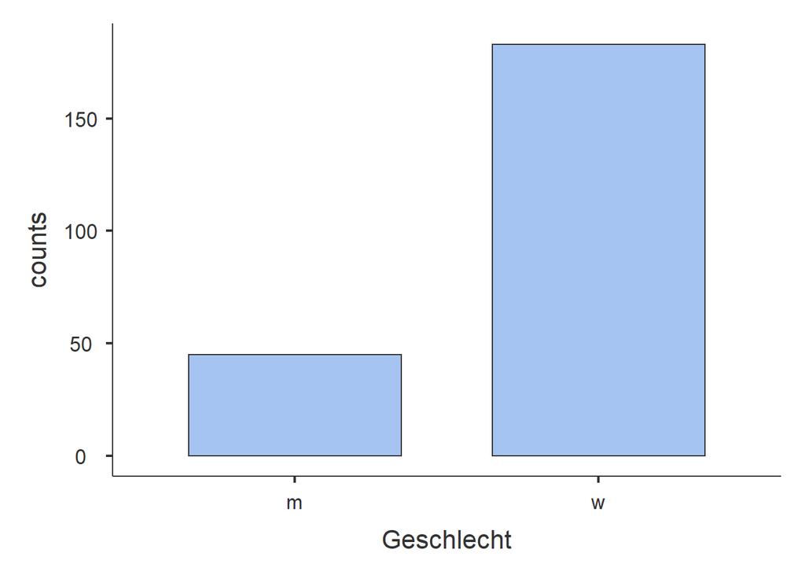

Mit korrekter Beschriftung würde die Grafik etwa so aussehen (Farben sind unwichtig)

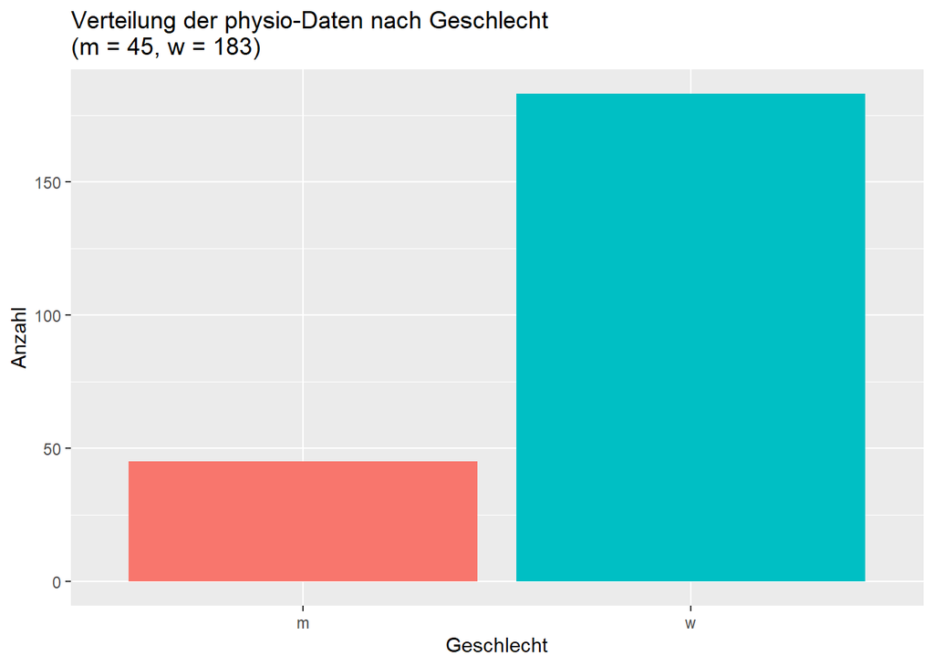

**Kopieren Sie den jamovi-Output in ein Word-Dokument und beschriften Sie Grafiken und Tabellen möglichst aussagekräftig.**

## Übung 3

### Aufgaben

1. Wie gross sind die absoluten und die relativen Häufigkeiten der drei Augenfarben?
2. Stellen Sie die Verteilung der Augenfarben in einer Grafik dar. Welches ist häufigste Augenfarbe?

### Lösungen

1. Wie gross sind die absoluten und die relativen Häufigkeiten der drei Augenfarben?

Descriptives > Augenfarbe als Variable auswählen > Häkchen bei `Frequency tables` setzen

```
##
##  DESCRIPTIVES
##
##  Descriptives
##  -------------------------
##               Augenfarbe
##  -------------------------
##    N                 228
##    Missing             0
##  -------------------------
##
##
##  FREQUENCIES
##
##  Frequencies of Augenfarbe
##  --------------------------------------------------
##    Levels    Counts    % of Total    Cumulative %
##  --------------------------------------------------
##    blau          99      43.42105        43.42105
##    braun         78      34.21053        77.63158
##    gruen         51      22.36842       100.00000
##  --------------------------------------------------
```

2. Stellen Sie die Verteilung der Augenfarben in einer Grafik dar. Welches ist häufigste Augenfarbe?

Descriptives > Augenfarbe als Variable auswählen > Häkchen bei `Frequency tables` setzen  
Häkchen unter `Plots` > `Bar plot` setzen

```
##
##  DESCRIPTIVES
```

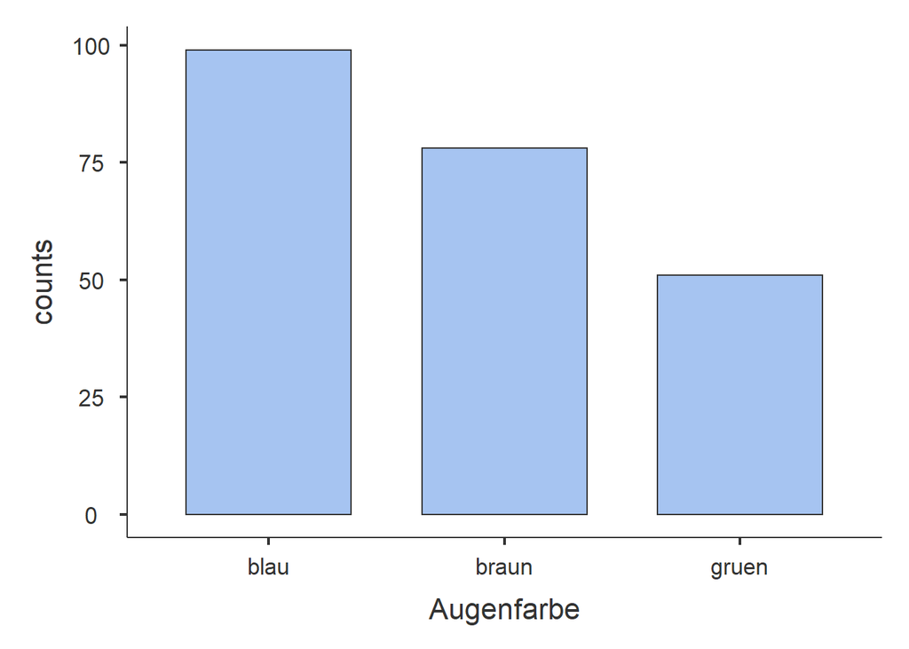

Vollständig beschriftet könnte die Grafik etwa so aussehen:

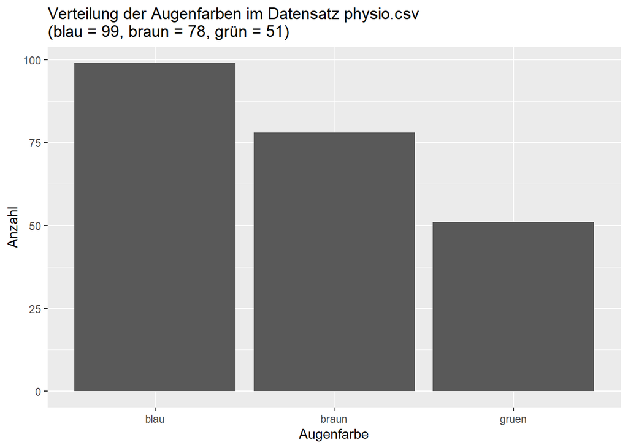

**Kopieren Sie den jamovi-Output in ein Word-Dokument und beschriften Sie Grafiken und Tabellen möglichst aussagekräftig.**

## Übung 4

### Aufgaben

1. Wie gross sind die Studierenden im Datensatz physio.csv? Fassen Sie das Ergebnis in einem Satz zusammen.
2. Stellen Sie die Verteilung der Körpergrösse in physio.csv anhand von zwei verschiedenen Grafiken dar. Beurteilen Sie die Symmetrie und interpretieren Sie die Verteilung.
3. Wie gross sind die Studierenden im Datensatz physio.csv? Trennen Sie nach Geschlecht und fassen Sie das Ergebnis in einem Satz zusammen.
4. Erstellen Sie zwei Grafiken zur Verteilung der Körpergrösse, nach Geschlecht getrennt.

### Lösungen

1. Wie gross sind die Studierenden im Datensatz physio.csv? Fassen Sie das Ergebnis in einem Satz zusammen.

Descriptives > Variable Groesse auswählen

```
##
##  DESCRIPTIVES
##
##  Descriptives
##  ----------------------------------
##                          Groesse
##  ----------------------------------
##    N                          228
##    Missing                      0
##    Mean                  169.4781
##    Median                168.0000
##    Standard deviation    7.764397
##    Minimum               148.0000
##    Maximum               198.0000
##  ----------------------------------
```

*Die durchschnittliche Körpergrösse der Studierenden in physio.csv beträgt 169 cm (s = 7.76)*

2. Stellen Sie die Verteilung der Körpergrösse in physio.csv anhand von zwei verschiedenen Grafiken dar. Beurteilen Sie die Symmetrie und interpretieren Sie die Verteilung.

Descriptives > Variable Groesse auswählen,  
Plots > Häkchen bei `Histogram` und `Boxplot` setzen.

```
##
##  DESCRIPTIVES
```

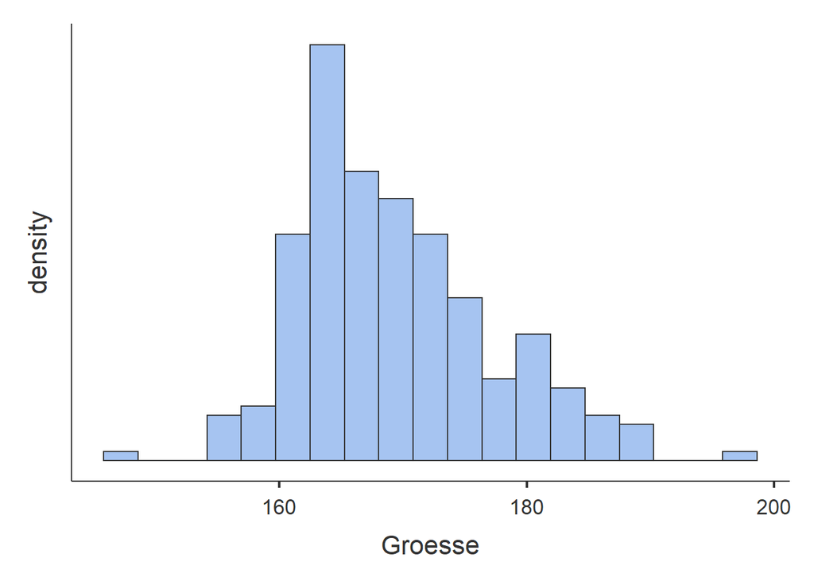

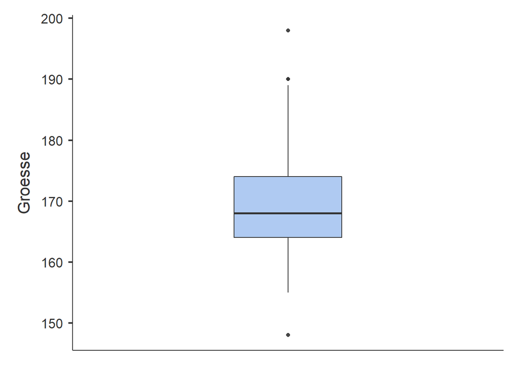

Vollständig beschriftet könnten die Grafiken etwa so aussehen:

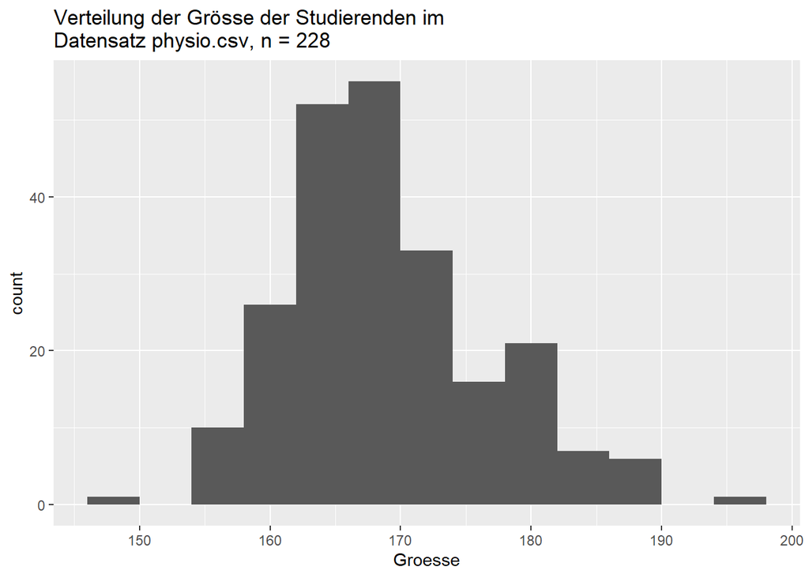

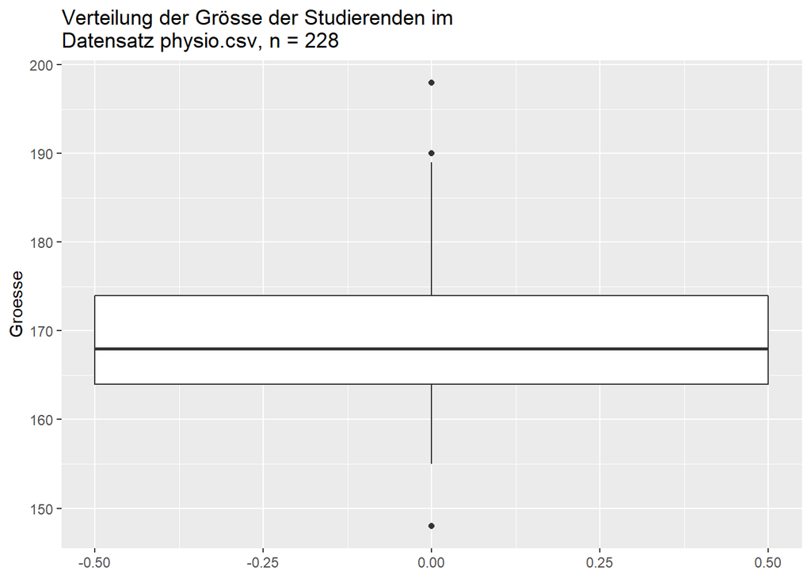

*Wie beurteilen Sie die Symmetrie der Verteilung der Körpergrösse?*

3. Wie gross sind die Studierenden im Datensatz physio.csv? Trennen Sie nach Geschlecht und fassen Sie das Ergebnis in einem Satz zusammen.

Descriptives > Grösse als Variable auswählen, Geschlecht als `Split by`-Variable wählen

```
##
##  DESCRIPTIVES
##
##  Descriptives
##  ------------------------------------------------
##                          Geschlecht    Groesse
##  ------------------------------------------------
##    N                     m                   45
##                          w                  183
##    Missing               m                    0
##                          w                    0
##    Mean                  m             179.8667
##                          w             166.9235
##    Median                m             180.0000
##                          w             167.0000
##    Standard deviation    m             6.387488
##                          w             5.664100
##    Minimum               m             169.0000
##                          w             148.0000
##    Maximum               m             198.0000
##                          w             183.0000
##  ------------------------------------------------
```

*Die durchschnittliche Körpergrösse der Studentinnen im Datensatz physio.csv beträgt 166.9 cm (s = 5.66 cm) und die der Studenten 179.9 cm (s = 6.39 cm).*

4. Erstellen Sie zwei Grafiken zur Verteilung der Körpergrösse, nach Geschlecht getrennt.

Descriptives > Grösse als Variable auswählen, Geschlecht als `Split by`-Variable wählen  
Plots > Häkchen bei `Histogram` und `Boxplot` setzen.

```
##
##  DESCRIPTIVES
```

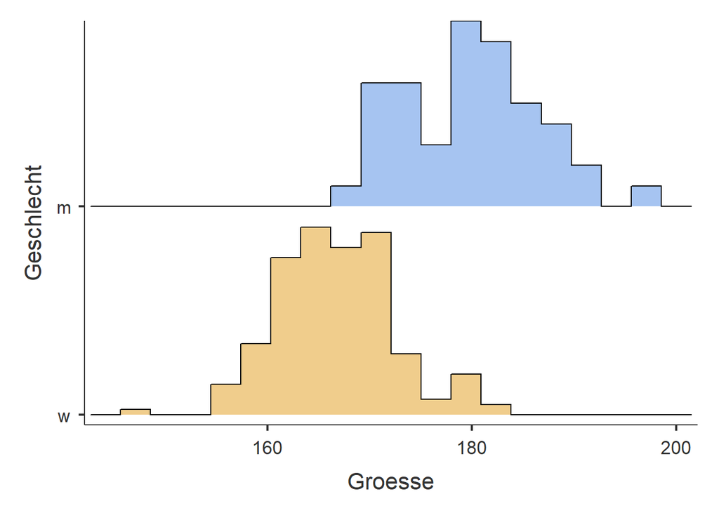

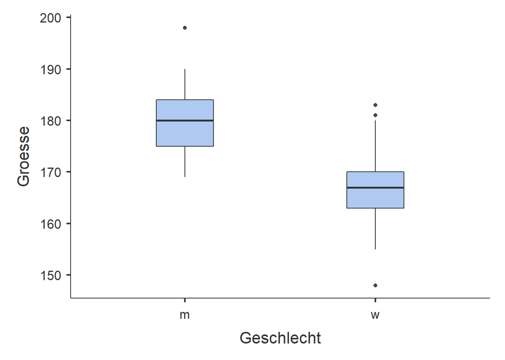

Vollständig beschriftet könnte die Grafik so aussehen (das Histogramm kann in dieser Form in jamovi nicht dargestellt werden):

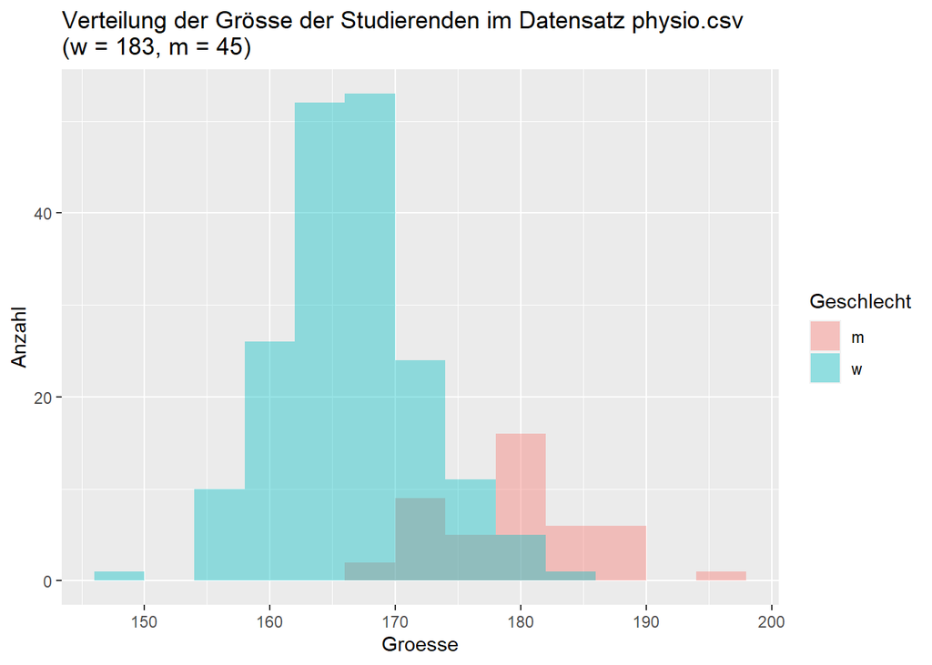

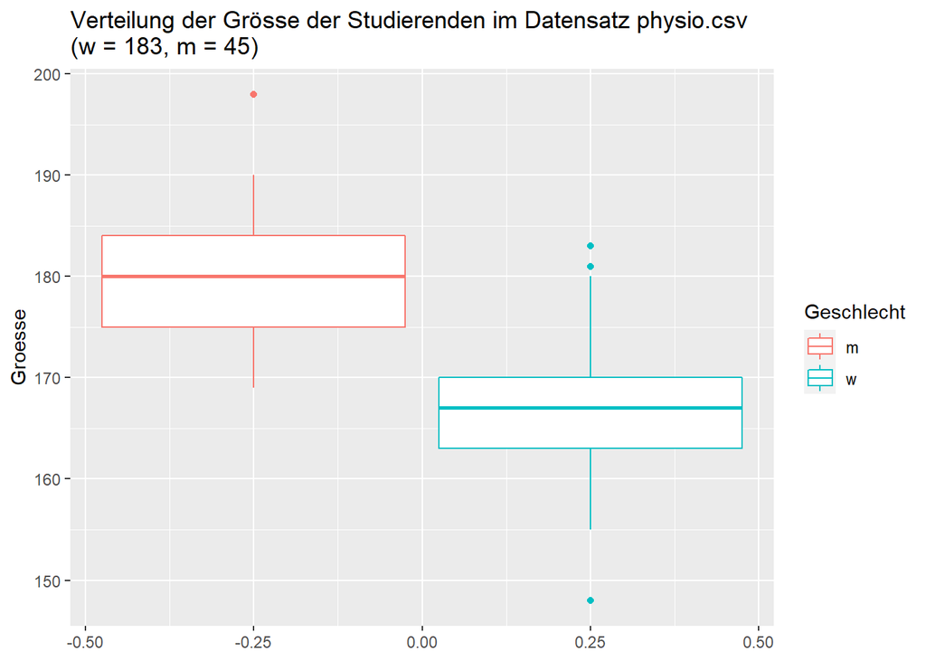

**Kopieren Sie den jamovi-Output in ein Word-Dokument und beschriften Sie Grafiken und Tabellen möglichst aussagekräftig.**

## Übung 5

### Aufgabe

Untersuchen Sie den Zusammenhang zwischen Körpergrösse und Körpergewicht der weiblichen Studierenden im Datensatz physio.csv.

### Lösung

Vorgehen

1. Erstellen Sie einen Filter in jamovi > Data > Filters mit der Formel: **= Geschlecht == “w”**
2. Unter `Exploration` wählen Sie `Scatterplot`.
3. Erstellen Sie ein Punktediagramm (Scatterplot) mit den Variablen Y-Axis: Gewicht und X-Axis: Groesse
4. Beschreiben Sie den Zusammenhang zwischen Körpergewicht und Körpergrösse.

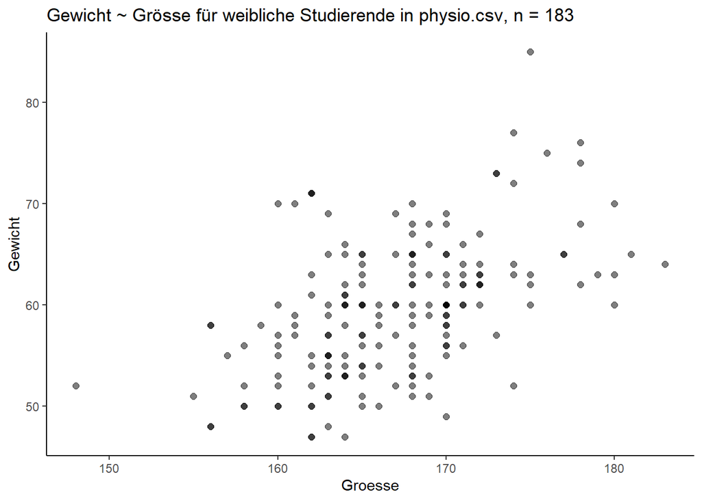

**Kopieren Sie den jamovi-Output in ein Word-Dokument und beschriften Sie Grafiken und Tabellen möglichst aussagekräftig.**

## Übung 6

### Aufgabe

Untersuchen Sie den Zusammenhang zwischen Körpergrösse und Schuhgrösse aller Beobachtungseinheiten in physio.csv.

### Lösung

Vorgehen:

1. Falls noch nicht geschehen, den Filter für nur weibliche Studierende deaktivieren.
2. Erstellen Sie ein Punktediagramm für Y-Axis: Schuhgroesse und X-Axis: Groesse nach Geschlecht gruppiert (Group: Geschlecht).
3. Beschreiben Sie den Zusammenhang zwischen Schuhgrösse und Körpergrösse.

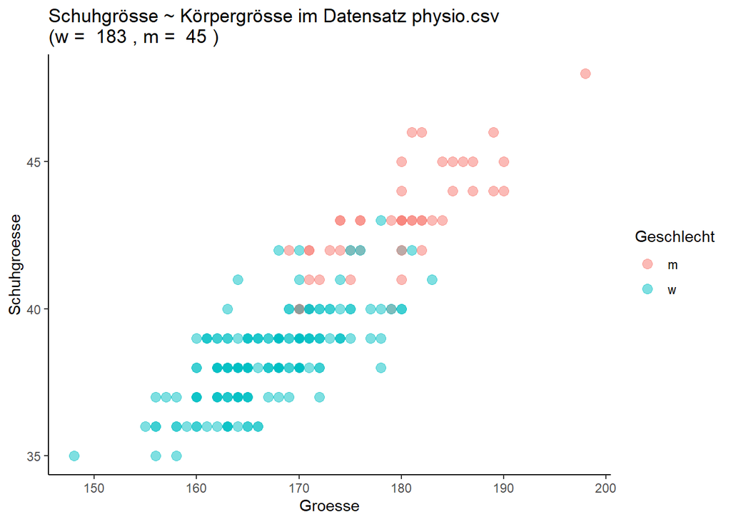

**Kopieren Sie den jamovi-Output in ein Word-Dokument und beschriften Sie Grafiken und Tabellen möglichst aussagekräftig.**